# Web_mining

### Text Scraping and Classification

### Imports

```python
import time
ticks = time.time()
```

```python
import pandas as pd
import numpy as np
from bs4 import BeautifulSoup
import urllib
from sklearn.model_selection import train_test_split
from sklearn.model_selection import cross_val_score
from sklearn.feature_extraction.text import TfidfVectorizer,CountVectorizer
from sklearn.naive_bayes import MultinomialNB
from sklearn import svm
from sklearn import ensemble
from sklearn import tree
from sklearn import neural_network
from sklearn import metrics
import matplotlib.pyplot as plt
import warnings
import os
from os import listdir
from os.path import isfile, join
%matplotlib inline

import nltk
```

## Part1: Data Collection

I am collecting different news articles and their associated labels by Web Mining using BeautifulSoup package.

Createing helper functions

```python
# urls from which we will be scrapping the articles
mainLink = "http://mlg.ucd.ie/modules/COMP41680/archive/index.html"
prefix = "http://mlg.ucd.ie/modules/COMP41680/archive/"
```

```python
# This function will remove the existing created .txt files
def clearDirecotry():
    filelist = [file for file in listdir("files/") if isfile(join("files/", file)) if file.endswith(".txt")]
    for filename in filelist:
        os.remove("files/"+filename)
    print("Files Removed Successfully!")
```

```python
# This function will append the article body in new line associated with it's label
def appendFile(fileName, body):
    fileName = "files/"+fileName+".txt"
    f = open(fileName, "a+", encoding="utf-8")
    f.write(body.strip())
    f.write("\n")
    f.close()
```

```python
# This function will fetch the content of the article and including it's heading and store it in body variable
def fetchBody(url, category):
    r = urllib.request.urlopen(url).read()
    soup = BeautifulSoup(r, "html.parser")
    letters = soup.find_all("p")
    body = soup.find("h2").get_text()    # fetching the H2 heading of the article
    for element in letters[:-1]:         #to skip the last comments / any part
        # for few articles the p tag has the repeated Headlines. I am not remoming it because it won't make any big differnt
        # for our corpus
        body = body + " " + element.get_text()
    appendFile(category, body)
```

I am storing the articles in three text files

- business.txt --> All the articles associated to business category will be stored in it
- sports.txt --> All the articles associated to sports category will be stored in it
- technology.txt --> All the articles associated to technology category will be stored in it
- The main URL is used for fetching web pages
- On the parent page, for fetching the month's URL I'm using LI tag and href attribute of Anchor tag
- Then on the first child page, for fetching the categories and article's link I'm using TR tag and it's category class and href attribute of Anchor tag
- Then on the second child page, for fetching the article's body I am using P tag and H2 tag for article's heading

```python
r = urllib.request.urlopen(mainLink).read()
soup = BeautifulSoup(r, "html.parser")
articles = soup.find_all("li")
# excpetion handling
try:
    # Here, I am fetching the month's URL from Parent page and storing into month_url_dict dictionary
    clearDirecotry()
    month_url_dict = {}
    for element in articles:                             # fetching of all urls from main page
        month = element.a.get_text().strip()
        month_url = element.a["href"].strip()
        month_url_dict[month] = prefix + month_url       # creating url for articles within months

    # For each month, I am accessing the first child webpage.
    for link in month_url_dict.values():
        r = urllib.request.urlopen(link).read()
        soup = BeautifulSoup(r, "html.parser")
        art_cat = soup.find_all("tr")                    # fetching all TR tags

        # For each month's article, fetching the second child webpage which has actual article body
        for element in art_cat[1:]:
            category = element.find(class_="category").get_text().strip()
            if category != "N/A":                        # skipping the N/A content
                art_url = element.find(class_="title").a["href"].strip()
                l = prefix + art_url                     # generating the valid url to fetch article body
                fetchBody(l, category)                   # calling the helper function to fetch the body associated with Article
    print("Articles have been successfuly saved")
except:
    print("something went wrong. Please try agian")
```

```
Files Removed Successfully!
Articles have been successfuly saved
```

I am creating the dynamic dataframe from text files which has articles body

```python
df = pd.DataFrame()                # this will hold the article's body and it's associated label
filelist = [file for file in listdir("files/") if isfile(join("files/", file)) if file.endswith(".txt")]
for filename in filelist:
    temp_df = pd.DataFrame()
    print(filename[:-4])
    body_list = []
    f = open("files/"+filename,"r", encoding="utf-8")
    for i in f.readlines():
        body_list.append(i.strip())
    temp_df["body"] = body_list             # column body will have article content
    temp_df["label"] = filename[:-4]        # column label will have article category
    df = pd.concat([df,temp_df])
```

```
business
sport
technology
```

```python
df.to_csv("files/corpus.csv", index=False)   # saving the corpus into CSV for future ref
df.head()
```

|  | body | label |
| --- | --- | --- |
| 0 | Asian quake hits European shares Asian quake h... | business |
| 1 | Barclays shares up on merger talk Barclays sha... | business |
| 2 | Bush budget seeks deep cutbacks Bush budget se... | business |
| 3 | Bush to get 'tough' on deficit Bush to get 'to... | business |
| 4 | Card fraudsters 'targeting web' Card fraudster... | business |

## Part 2: Text Classification

I am analysing the corpus of documents created in from Part 1 in a text classification context

### 2.1 Loading the dataset

```python
df = pd.read_csv('files/corpus.csv')
df = df.sample(frac=1)
print("shape of dataframe: ", df.shape)

X = df["body"]
Y = df["label"]

acc_dict = {}
f1_dict = {}
df.head()
```

```
shape of dataframe:  (1408, 2)
```

|  | body | label |
| --- | --- | --- |
| 1116 | Cyber crime booms in 2004 The last 12 months ... | technology |
| 1053 | Anti-spam screensaver scrapped Anti-spam scree... | technology |
| 1229 | Latest Opera browser gets vocal Net browser O... | technology |
| 596 | Collins named UK Athletics chief UK Athletics... | sport |
| 643 | Ireland v USA (Sat) Ireland v USA (Sat) Satur... | sport |

Data distribution

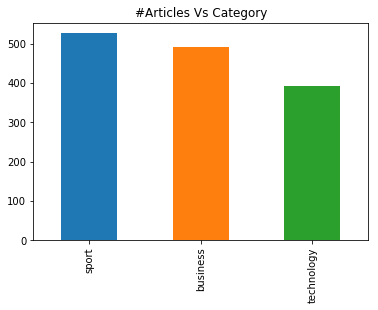

```python
df["label"].value_counts().plot.bar(title = "#Articles Vs Category")
plt.show()
```

Our data distribution is imbalanced. So, I will be taking F1 score along with Accuracy measure

### 2.2 Document-Term Matrix Representation:

I have used total 6 text pre-processing steps on the corpus and created DTM.

- Tokenization & Case Conversion: Handled by Sklearn
- Stop Words removal: Filtered 'english' stop words
- Infrequent term removal: Provided the threshold of 4 to 'min_df' argument
- Lemmatization: Used the lemma (root) of terms by building Lemmatizer from NLTK package
- Ngram : To get more context of corpus I've used 1 and 2 gram terms

Split the data into a **training set** and a **test set**

```python
X_train, X_test, y_train, y_test = train_test_split(X, Y,test_size=0.30)
```

As we are using the TFIDF so we are crating the tokenizer from TfidfVectorizer instead of CountVectorizer

```python
def lemma_tokenizer(text):
    # use the standard scikit-learn tokenizer first
    standard_tokenizer = TfidfVectorizer().build_tokenizer()
    tokens = standard_tokenizer(text)
    # then use NLTK to perform lemmatisation on each token
    lemmatizer = nltk.stem.WordNetLemmatizer()
    lemma_tokens = []
    for token in tokens:
        lemma_tokens.append( lemmatizer.lemmatize(token) )
    return lemma_tokens
```

Inverse Document Frequency (TF-IDF) is more meaningful than Term Frequency (TF) so I have created Document Term Matrix of TF-IDF scores using Sklearn package

```python
# created the DTM of TFIDF
vectorizer = TfidfVectorizer(lowercase=True, min_df = 4, stop_words="english", tokenizer=lemma_tokenizer, ngram_range=(1, 2))
#vectorizer = CountVectorizer(stop_words="english",min_df = 3,tokenizer=lemma_tokenizer)
count_dataset = vectorizer.fit_transform(X)  # entire data set for CV fold
print("Shape of Entire dataset ",count_dataset.shape)

count_train = vectorizer.transform(X_train)
print("Shape of Training dataset ", count_train.shape)
count_test = vectorizer.transform(X_test)
print("Shape of Testing dataset ", count_test.shape)
```

```
Shape of Entire dataset  (1408, 13254)
Shape of Training dataset  (985, 13254)
Shape of Testing dataset  (423, 13254)
```

```python
# TFIDF score of few terms
print(count_train[0:7,30:40])
```

[output not shown]

### 2.3. Multi-Class Classification models:

I have used 4 different Multi-Class Classification models for this task:

- Multinomial NB - Flavor of Naive Bayes classifier which works better with Text data
- Simple Decision Tree - With default hyper-parameters
- Support Vector Machine - With linear kernel
- Neural Network - With default hyper-parameters

Evaluation methods:

- **One-Way Holdout Strategy** by splitting data into Traning and Testing dataset.
- **K-fold cross-validation** using K=5

#### MultinomialNB

```python
nb_classifier = MultinomialNB()
nb_classifier.fit(count_train, y_train)
```

```
MultinomialNB(alpha=1.0, class_prior=None, fit_prior=True)
```

Evaluation on the holdout test dataset

```python
# Make a set of predictions for the training data
y_pred = nb_classifier.predict(count_test)

# Print performance details
accuracy = metrics.accuracy_score(y_test, y_pred) # finding accuracy i
print("Accuracy: " +  str(accuracy))
print(metrics.classification_report(y_test, y_pred))

# Print confusion matrix
print(metrics.confusion_matrix(y_test, y_pred))

# Print nicer homemade confusion matrix
print("Confusion Matrix")
pd.crosstab(y_test, y_pred, rownames=['True'], colnames=['Predicted'], margins=True)
```

```
Accuracy: 0.978723404255
             precision    recall  f1-score   support

   business       0.98      0.98      0.98       139
      sport       0.98      0.99      0.99       167
 technology       0.98      0.96      0.97       117

avg / total       0.98      0.98      0.98       423

[[136   1   2]
 [  1 166   0]
 [  2   3 112]]
Confusion Matrix
```

| Predicted True | business | sport | technology | All |
| --- | --- | --- | --- | --- |
| business | 136 | 1 | 2 | 139 |
| sport | 1 | 166 | 0 | 167 |
| technology | 2 | 3 | 112 | 117 |
| All | 139 | 170 | 114 | 423 |

#### Cross Validation by accuracy and f1 scoring metrics

```python
scores = cross_val_score(nb_classifier, count_dataset, Y, cv=5, scoring="accuracy")
print("Accuracy scores: ", scores)
# Calculate the average accuracy across all folds:
print("MultinomialNB: Mean cross-validation accuracy = {}".format(scores.mean() ))
acc_dict["MultinomialNB"] = scores.mean()
print()

# Calculate the average f1_weighted score across all folds:
# Calculating metrics for each label, and finding their average, weighted by support.
scores = cross_val_score(nb_classifier, count_dataset, Y, cv=5, scoring="f1_weighted")
print("F1_weighted scores: ", scores)
print("MultinomialNB: Mean cross-validation f1 score = {}".format(scores.mean() ))
f1_dict["MultinomialNB"] = scores.mean()
```

```
Accuracy scores:  [ 0.98591549  0.97864769  0.97864769  0.96797153  0.98932384]
MultinomialNB: Mean cross-validation accuracy = 0.9801012480577415

F1_weighted scores:  [ 0.98590665  0.9786105   0.97861559  0.96802728  0.98929784]
MultinomialNB: Mean cross-validation f1 score = 0.9800915695028
```

#### Simple Decision Tree

```python
my_tree = tree.DecisionTreeClassifier(criterion="entropy")
my_tree = my_tree.fit(count_train, y_train)
```

Evaluation on the holdout test dataset

```python
# Make a set of predictions for the training data
y_pred = my_tree.predict(count_test)

# Print performance details
accuracy = metrics.accuracy_score(y_test, y_pred) # , normalize=True, sample_weight=None
print("Accuracy: " +  str(accuracy))
print(metrics.classification_report(y_test, y_pred))

# Print confusion matrix
print(metrics.confusion_matrix(y_test, y_pred))

# Print nicer homemade confusion matrix
print("Confusion Matrix")
pd.crosstab(y_test, y_pred, rownames=['True'], colnames=['Predicted'], margins=True)
```

```
Accuracy: 0.926713947991
             precision    recall  f1-score   support

   business       0.88      0.94      0.91       139
      sport       0.95      0.96      0.96       167
 technology       0.94      0.87      0.91       117

avg / total       0.93      0.93      0.93       423

[[130   4   5]
 [  6 160   1]
 [ 11   4 102]]
Confusion Matrix
```

| Predicted True | business | sport | technology | All |
| --- | --- | --- | --- | --- |
| business | 130 | 4 | 5 | 139 |
| sport | 6 | 160 | 1 | 167 |
| technology | 11 | 4 | 102 | 117 |
| All | 147 | 168 | 108 | 423 |

#### Cross Validation by accuracy and f1 scoring metrics

```python
scores = cross_val_score(my_tree, count_dataset, Y, cv=5, scoring="accuracy")
print("Accuracy scores: ", scores)
# Calculate the average accuracy across all folds:
print("Decision Tree: Mean cross-validation accuracy = {}".format(scores.mean() ))
acc_dict["Decision Tree"] = scores.mean()
print()

# Calculate the average f1_weighted score across all folds:
# Calculating metrics for each label, and finding their average, weighted by support.
scores = cross_val_score(my_tree, count_dataset, Y, cv=5, scoring="f1_weighted")
print("F1_weighted scores: ", scores)
print("Decision Tree: Mean cross-validation f1 score = {}".format(scores.mean() ))
f1_dict["Decision Tree"] = scores.mean()
```

```
Accuracy scores:  [ 0.91549296  0.91103203  0.87900356  0.88967972  0.85765125]
Decision Tree: Mean cross-validation accuracy = 0.8905719011578366

F1_weighted scores:  [ 0.91543306  0.91092072  0.87123954  0.88615796  0.86467416]
Decision Tree: Mean cross-validation f1 score = 0.8896850891849132
```

#### Support Vector Machine

```python
my_svm = svm.SVC(kernel="linear")
my_svm.fit(count_train, y_train)
```

```
SVC(C=1.0, cache_size=200, class_weight=None, coef0=0.0,
  decision_function_shape='ovr', degree=3, gamma='auto', kernel='linear',
  max_iter=-1, probability=False, random_state=None, shrinking=True,
  tol=0.001, verbose=False)
```

Evaluation on the holdout test dataset

```python
# Make a set of predictions for the training data
y_pred = my_svm.predict(count_test)

# Print performance details
accuracy = metrics.accuracy_score(y_test, y_pred) # , normalize=True, sample_weight=None
print("Accuracy: " +  str(accuracy))
print(metrics.classification_report(y_test, y_pred))

# Print confusion matrix
print(metrics.confusion_matrix(y_test, y_pred))

# Print nicer homemade confusion matrix
print("Confusion Matrix")
pd.crosstab(y_test, y_pred, rownames=['True'], colnames=['Predicted'], margins=True)
```

```
Accuracy: 0.983451536643
             precision    recall  f1-score   support

   business       0.99      0.98      0.98       139
      sport       0.98      0.99      0.99       167
 technology       0.99      0.97      0.98       117

avg / total       0.98      0.98      0.98       423

[[136   2   1]
 [  1 166   0]
 [  1   2 114]]
Confusion Matrix
```

| Predicted True | business | sport | technology | All |
| --- | --- | --- | --- | --- |
| business | 136 | 2 | 1 | 139 |
| sport | 1 | 166 | 0 | 167 |
| technology | 1 | 2 | 114 | 117 |
| All | 138 | 170 | 115 | 423 |

#### Cross Validation by accuracy and f1 scoring metrics

```python
scores = cross_val_score(my_svm, count_dataset, Y, cv=5, scoring="accuracy")
print("Accuracy scores: ", scores)
# Calculate the average accuracy across all folds:
print("SVM: Mean cross-validation accuracy = {}".format(scores.mean() ))
acc_dict["SVM"] = scores.mean()
print()

# Calculate the average f1_weighted score across all folds:
# Calculating metrics for each label, and finding their average, weighted by support.
scores = cross_val_score(my_svm, count_dataset, Y, cv=5, scoring="f1_weighted")
print("F1_weighted scores: ", scores)
print("SVM: Mean cross-validation f1 score = {}".format(scores.mean() ))
f1_dict["SVM"] = scores.mean()
```

```
Accuracy scores:  [ 0.98591549  0.98932384  0.97508897  0.97153025  0.98932384]
SVM: Mean cross-validation accuracy = 0.9822364793744676

F1_weighted scores:  [ 0.98590665  0.98933047  0.97506087  0.9715911   0.98929844]
SVM: Mean cross-validation f1 score = 0.9822375041735943
```

#### Artificial Neural Network

```python
my_nn = neural_network.MLPClassifier()
my_nn.fit(count_train, y_train)
```

```
MLPClassifier(activation='relu', alpha=0.0001, batch_size='auto', beta_1=0.9,
       beta_2=0.999, early_stopping=False, epsilon=1e-08,
       hidden_layer_sizes=(100,), learning_rate='constant',
       learning_rate_init=0.001, max_iter=200, momentum=0.9,
       nesterovs_momentum=True, power_t=0.5, random_state=None,
       shuffle=True, solver='adam', tol=0.0001, validation_fraction=0.1,
       verbose=False, warm_start=False)
```

Evaluation on the holdout test dataset

```python
# Make a set of predictions for the training data
y_pred = my_nn.predict(count_test)

# Print performance details
accuracy = metrics.accuracy_score(y_test, y_pred) # , normalize=True, sample_weight=None
print("Accuracy: " +  str(accuracy))
print(metrics.classification_report(y_test, y_pred))

# Print confusion matrix
print(metrics.confusion_matrix(y_test, y_pred))

# Print nicer homemade confusion matrix
print("Confusion Matrix")
pd.crosstab(y_test, y_pred, rownames=['True'], colnames=['Predicted'], margins=True)
```

```
Accuracy: 0.988179669031
             precision    recall  f1-score   support

   business       0.99      0.99      0.99       139
      sport       0.98      0.99      0.99       167
 technology       0.99      0.98      0.99       117

avg / total       0.99      0.99      0.99       423

[[137   1   1]
 [  1 166   0]
 [  0   2 115]]
Confusion Matrix
```

| Predicted True | business | sport | technology | All |
| --- | --- | --- | --- | --- |
| business | 137 | 1 | 1 | 139 |
| sport | 1 | 166 | 0 | 167 |
| technology | 0 | 2 | 115 | 117 |
| All | 138 | 169 | 116 | 423 |

#### Cross Validation by accuracy and f1 scoring metrics

```python
scores = cross_val_score(my_nn, count_dataset, Y, cv=5, scoring="accuracy")
print("Accuracy scores: ", scores)
# Calculate the average accuracy across all folds:
print("MLP: Mean cross-validation accuracy = {}".format(scores.mean() ))
acc_dict["MLP"] = scores.mean()
print()

# Calculate the average f1_weighted score across all folds:
# Calculating metrics for each label, and finding their average, weighted by support.
scores = cross_val_score(my_nn, count_dataset, Y, cv=5, scoring="f1_weighted")
print("F1_weighted scores: ", scores)
print("MLP: Mean cross-validation f1 score = {}".format(scores.mean() ))
f1_dict["MLP"] = scores.mean()
```

```
Accuracy scores:  [ 0.98239437  0.98576512  0.97508897  0.97508897  0.99288256]
MLP: Mean cross-validation accuracy = 0.9822439977945967

F1_weighted scores:  [ 0.98590665  0.98223598  0.97867881  0.9715911   0.99643823]
MLP: Mean cross-validation f1 score = 0.9829701539117878
```

### 2.4. Evaluating Performance of Classifiers

For evaluation purpose, I have used two strategies

One-Way Holdout Strategy:  
I have used 70-30 split and trained the models using 70% of data and evaluated performance on 30% of holdout test data.

5-fold Cross Validation:  
I have used 5 fold CV on the entire dataset. Cross-validation strategy is **more robust** than One-Way holdout strategy. So, using the mean accuracy score of CV for analysis.

```python
acc_dict
```

```
{'Decision Tree': 0.89057190115783658,
 'MLP': 0.9822439977945967,
 'MultinomialNB': 0.98010124805774146,
 'SVM': 0.98223647937446756}
```

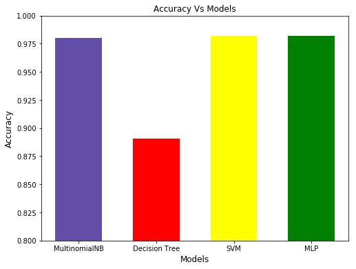

```python
classifiers = acc_dict.keys()
x_position = np.arange(len(classifiers))
accuracy_values = acc_dict.values()
plt.figure(figsize=(8,6))
plt.bar(x_position, accuracy_values, align='center', width=0.6, color= ['#624ea7', 'red', 'yellow', 'green'])
plt.xticks(x_position, classifiers)
plt.xlabel('Models', fontsize='12')
plt.ylabel('Accuracy', fontsize='12')
plt.ylim(0.8, 1)
plt.title('Accuracy Vs Models',fontsize='12')
plt.show()
```

```python
f1_dict
```

```
{'Decision Tree': 0.88968508918491318,
 'MLP': 0.98297015391178777,
 'MultinomialNB': 0.98009156950279996,
 'SVM': 0.98223750417359434}
```

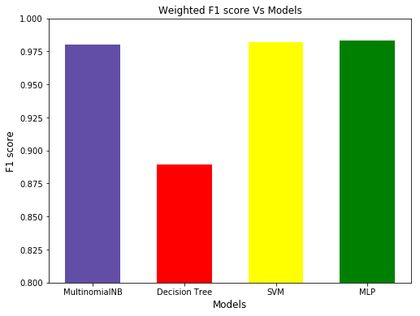

```python
classifiers = f1_dict.keys()
x_position = np.arange(len(classifiers))
accuracy_values = f1_dict.values()
plt.figure(figsize=(8,6))
plt.bar(x_position, accuracy_values, align='center', width=0.6,  color= ['#624ea7', 'red', 'yellow', 'green'])
plt.xticks(x_position, classifiers)
plt.xlabel('Models', fontsize='12')
plt.ylabel('F1 score', fontsize='12')
plt.ylim(0.8, 1)
plt.title('Weighted F1 score Vs Models',fontsize='12')
plt.show()
```

```python
tocks = time.time()
mins = (tocks-ticks) / 60
print("time taken to run entire note book is {0:.2f} minutes".format(mins))
```

```
time taken to run entire note book is 7.71 minutes
```

## Observations

- Multinomial Navie Bayes is variant of naive Bayes which is widely used for topic modelling. Naive Bayes treat terms independent which might miss the context of the word which depends on previous words but surprisingly for our corpus it worked well.
- Decision Tree doesn't perform too well on given dataset compared to other three classifiers.
- SVM with hyperparameter Kernal="linear" gave almost 98% accuracy
- My favourite model, MLP works almost as good as SVM with default parameters and on such small dataset (1408 examples). By further tuning hyperparameters, we could achieve better model.

## Conclusion

- As data labels are not uniformly distributed so Accuracy is not the best measure for evaluation. So, I have considered the Weighted F1 score.
- Though for our dataset, the F1 and accuracy scores are almost similar there is no significant difference.
- Performance of Multinomial NB, MLP and SVM classifiers is far better than the Decision tree
- SVM's linear kernel is computationally very cheap and works better with text.
- To get the better insight of relationship between words for text classification using of 2-gram words is helpful
- We can say that our all models are performing too well on this small corpus and this might not be the case when we are classiying the articles which comes from differnt data distribution.